Álgebra Linear com Python

# Estudando a Biblioteca Matplotlib

Neste módulo, vamos analisar algumas funções pertencentes a biblioteca Matplotlib. É pertinente saber que tal biblioteca nos permite implementar ótimos gráficos e, através dela, reproduzir inúmeros dados de forma mais clara.

> `Versão do Python:` 3.x

```python
# importando o pacote matplotlib
import matplotlib.pyplot as plt
# definindo o backend do matplotlib no arquivo jupyter
%matplotlib inline
```

### Scatter

Vamos agora fazer uma plotagem de apenas um ponto, passando suas coordenadas no plano cartesiano.

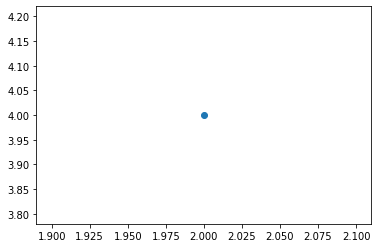

```python
x, y = 2., 4.
plt.scatter(x,y)
```

Ou então, podemos criar uma lista de coordenadas, de modo que podemos reduzir o nosso trabalha de plotar individualmente diversos pontos.

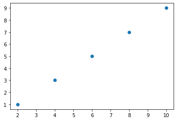

```python
x = [2.0, 4.0, 6.0, 8.0 , 10.0]
y = [1.0, 3.0, 5.0, 7.0, 9.0]
plt.scatter(x,y)
```

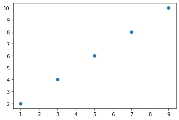

```python
plt.scatter(y,x)
```

### Função plot

Vamos agora utilizar a mesma lista para plotar o nosso gráfico de outra forma. A função scatter plota unicamente todos os pontos informados a ela, mas há outra função que plota um gráfico que liga todos os pontos, na respectiva ordem informada, vamos utilizar o método `plot()`.

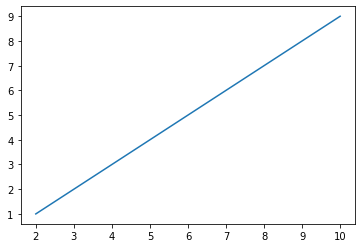

```python
plt.plot(x,y)
```

Observe que o gráfico está obedecendo corretamente as nossas listas que formam as coordenadas `(x,y)`. Entretanto, o gráfico está com pouca personalização.

### Personalizando o gráfico

Vamos começar colocando uma legenda ao nosso gráfico, de modo a torná-lo mais informativo:

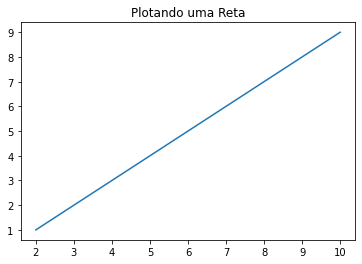

```python
plt.plot(x,y)
plt.title("Plotando uma Reta")
```

É possível modificar a cor da reta plotada. Para fazer isso, devemos utilizar o argumento `color`.

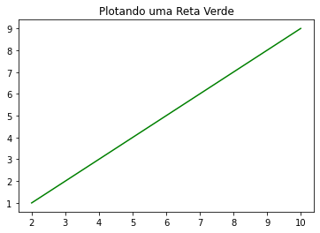

```python
plt.plot(x, y, color = "green")
plt.title("Plotando uma Reta Verde")
```

Também há a opção de se colocar uma grade ao nosso gráfico, de forma que podemos observar melhor a localização ponto a ponto.

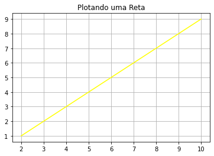

```python
plt.plot(x, y, color = "yellow")
plt.title("Plotando uma Reta")
plt.grid(True)
```

Do mesmo modo, temos uma caixa preta que moldura todo o gráfico. Há a opção de remové-la do nosso gráfico.

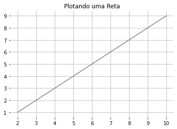

```python
plt.plot(x, y, color = "gray")
plt.title("Plotando uma Reta")
plt.grid(True)
plt.box(False)
```

Essas personalizações não estão unicamente restritas ao método `plot()`. Também podemos utilizá-las em outros métodos, como a `scatter()` ou outras que serão apresentadas mais a diante.

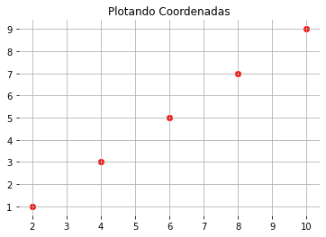

```python
plt.scatter(x, y, color = "red")
plt.title("Plotando Coordenadas")
plt.grid(True)
plt.box(False)
```

Caso seja pertinente, é possível também ocultar os valores de cada eixo:

```
([], [])
```

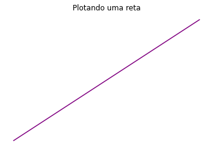

```python
plt.plot(x, y, color = "purple")
plt.title("Plotando uma reta")
plt.grid(True)
plt.box(False)
plt.xticks([],[])
plt.yticks([],[])
```

### Legendas no gráfico

Um outro recurso que pode ser de grande ajuda para leitura dos gráficos, são as legendas. Nela podemos informar uma breve descrição sobre o que tal gráfico legendado está representando.

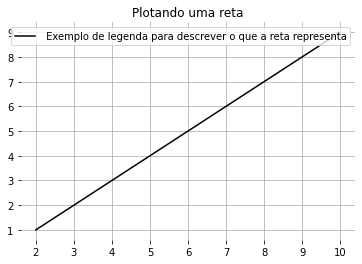

```python
plt.plot(x, y, color = "black", label = " Exemplo de legenda para descrever o que a reta representa")
plt.title("Plotando uma reta")
plt.grid(True)
plt.box(False)
plt.legend()
```

Para melhorar o nosso gráfico, devemos observar que a legenda é grande demais para o espaço utilizado. Vamos agora aprender a modificar os valores das dimensões do gráfico.

### Altura e largura do gráfico

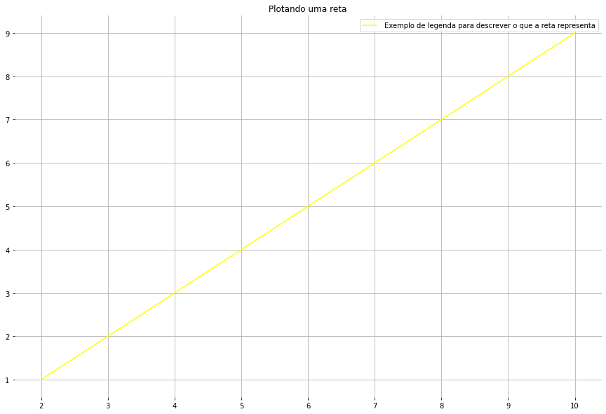

```python
plt.figure(figsize = (15,10))
plt.plot(x, y, color = "yellow", label = " Exemplo de legenda para descrever o que a reta representa")
plt.title("Plotando uma reta")
plt.grid(True)
plt.box(False)
plt.legend()
```

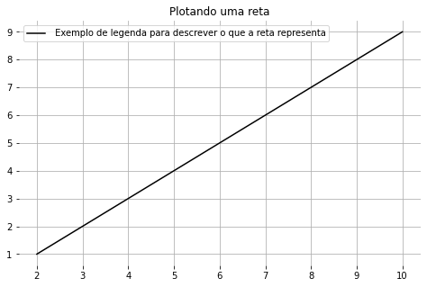

```python
plt.figure(figsize = (8,5))
plt.plot(x, y, color = "black", label = " Exemplo de legenda para descrever o que a reta representa")
plt.title("Plotando uma reta")
plt.grid(True)
plt.box(False)
plt.legend()
```

### Dois gráficos em um só

Podemos plotar dois gráfico em um só. Para visualizar isso, vamos criar uma situação abaixo em que uma empresa de celulares de nome Viciocell tem três marcas de produtos e, para cada uma delas, foi obtido os valores gastos na produção mês a mês. Devemos colocar todos esses dados em um gráfico, de forma que seja possível analisar melhor todo o rendimento da empresa durante o ano.

```python
ApplePhone = [8.3, 9.6, 20.9, 18.1, 5.0, 24.9, 35.2, 30.1, 10.7, 8.7, 8.3, 13.1]
XionesPhone = [4.1, 4.2, 10.3, 10.0, 3.6, 14.7 , 30.2, 10.9, 6.8, 2.3, 4.2, 12.7]
BikePhone = [1.0, 4.5, 7.8, 3.7, 7.8, 20.0, 39.0, 12.0, 14.5, 3.7, 2.2, 1.1]
```

```python
meses = ["Janeiro", "Fevereiro", "Março", "Abril", "Maio", "Junho", "Julho", "Agosto", "Setembro",
        "Outubro", "Novembro", "Dezembro"]
```

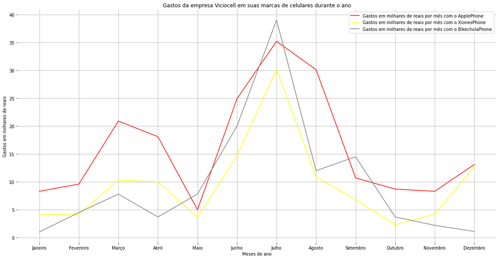

```python
plt.figure(figsize = (20,10))
plt.plot(meses, ApplePhone, color = "red", label = "Gastos em milhares de reais por mês com o ApplePhone")
plt.plot(meses, XionesPhone, color = "yellow",
         label = "Gastos em milhares de reais por mês com o XionesPhone")
plt.plot(meses, BikePhone, color = "gray",
         label = "Gastos em milhares de reais por mês com o BikecholaPhone")
plt.title("Gastos da empresa Viciocell em suas marcas de celulares durante o ano")
plt.grid(True)
plt.box(False)
plt.legend()
plt.xlabel("Meses do ano")
plt.ylabel("Gastos em milhares de reais")
```

### Gráficos a partir de funções

Podemos representar o compartamento de funções usando o matplotlib.

Vamos considerar as seguintes funções:

- $$f(x) = x^{2}sen(\frac{1}{x})$$
- $$f(x) = x^{2}cos(\frac{1}{x})$$

e para isso, devemos usar algumas funções da biblioteca numpy, já apresentadas em um programa anterior.

```python
from numpy import linspace, sin, cos
```

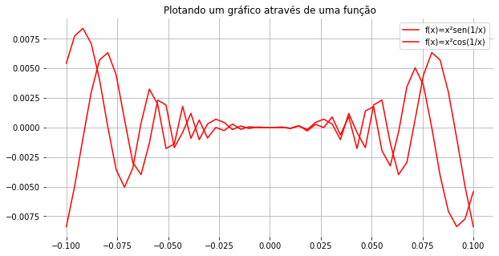

```python
plt.figure(figsize = (10,5))
valoresX = linspace(-0.10, 0.10)
plt.plot(valoresX, (valoresX ** 2) * sin(1 / valoresX), color = "Red", label = "f(x)=x²sen(1/x)")
plt.plot(valoresX, (valoresX ** 2) * cos(1 / valoresX), color = "Red", label = "f(x)=x²cos(1/x)")
plt.title("Plotando um gráfico através de uma função")
plt.grid(True)
plt.box(False)
plt.legend()
```

### Outros tipos de gráficos

- `Gráfico de Barras (função bar)`

Vamos plotar um gráfico de barras, para isso, vamos hipotetizar uma situação em que teremos a quantidade de horas de estudo que um universitário deve dedicar por dia para aprender bem as disciplinas no curso de engenharia elétrica da UFCG.

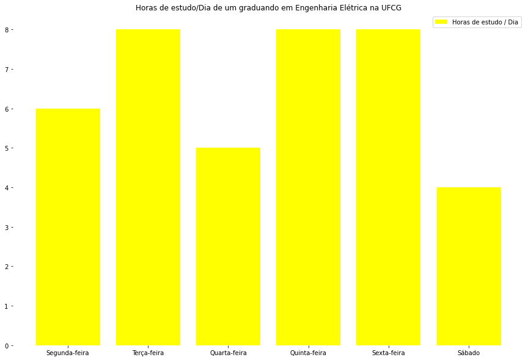

```python
dias = ["Segunda-feira", "Terça-feira", "Quarta-feira", "Quinta-feira", "Sexta-feira", "Sábado"]
horas = [6.0, 8.0, 5.0, 8.0, 8.0, 4.0]
plt.figure(figsize = (15,10))
plt.bar(dias, horas, color = "yellow", label = "Horas de estudo / Dia")
plt.grid(False)
plt.box(False)
plt.title("Horas de estudo/Dia de um graduando em Engenharia Elétrica na UFCG")
plt.legend()
```

- `Gráfico de Pizza`

Vamos plotar um gráfico no estilo "pizza", usando os mesmos dados anteriores.

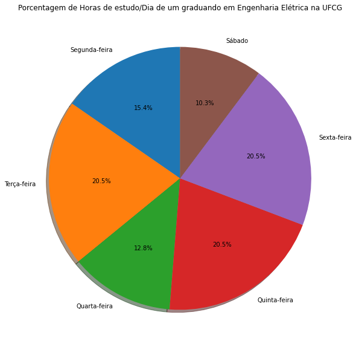

```python
plt.figure(figsize = (15,10))
plt.pie(horas, labels = dias, autopct = '%1.1f%%', shadow = True, startangle = 90)
plt.title("Porcentagem de Horas de estudo/Dia de um graduando em Engenharia Elétrica na UFCG")
```

### Salvando Gráficos

Caso seja necessário salvar os gráficos criados para exportar em outros documentos, o matplotlib oferece um método para isso. Ao final dos códigos de plotagem de um gráfico, use o método `savefig()`.

```python
plt.savefig('nome_da_figura')
```

### Alguma Dúvida? Entre em Contato Comigo: Me envie um e-mail

### Extra

- [Documentação do matplotlib](https://matplotlib.org/3.1.1/index.html)
- [Projeto do matplotlib no GitHub](https://github.com/matplotlib/matplotlib)